# Variables Categoricas

Andre Jo 22199, Nelson Escalante 22046, Jose Prince 22087

2025-03-24

Se decodificaran las variables categoricas con el proposito de que el analisis sea mas claro.

Se estaran utilizando las siguientes variables para realizar un analisis categorico: “DEPREG”, “MUPREG”, “DEPOCU”, “MUPOCU”,“PUEHOM”, “PUEMUJ”, “NACHOM”, “NACMUJ”,“ESCHOM”, “ESCMUJ”, “CIUOHOM”, “CIUOMUJ”

```
##      DEPREG MUPREG        DEPOCU MUPOCU           PUEHOM           PUEMUJ
## 1 Guatemala    101 Huehuetenango   1301         Ignorado         Ignorado
## 2 Guatemala    101     Guatemala    101         Ignorado         Ignorado
## 3    Zacapa   1901        Zacapa   1901 Mestizo / Ladino Mestizo / Ladino
## 4 Guatemala    101     Guatemala    115         Ignorado         Ignorado
## 5   Jutiapa   2204       Jutiapa   2206 Mestizo / Ladino Mestizo / Ladino
## 6 Guatemala    101       Jutiapa   2201         Ignorado         Ignorado
##   NACHOM NACMUJ  ESCHOM   ESCMUJ CIUOHOM CIUOMUJ
## 1    320    320 Ninguno Ingorado    99.0    23.0
## 2    840    320 Ninguno Ingorado    99.0    41.0
## 3    320    320 Ninguno Ingorado    99.0    98.0
## 4    320    320 Ninguno Ingorado    99.0    98.0
## 5    320    320 Ninguno Ingorado    99.0    99.0
## 6    320    320 Ninguno Ingorado    99.0    99.0
```

## Cuantos registros de divorcios hay en cada departamento?

```
##            DEPREG Frecuencia
## 1    Alta Verapaz       1731
## 2    Baja Verapaz       1418
## 3   Chimaltenango       1801
## 4      Chiquimula       2012
## 5     El Progreso       1485
## 6       Escuintla       3598
## 7       Guatemala      31204
## 8   Huehuetenango       2792
## 9          Izabal       2578
## 10         Jalapa       2029
## 11        Jutiapa       2982
## 12          Petén       2356
## 13 Quetzaltenango       6827
## 14         Quiché       2239
## 15     Retalhuleu       2460
## 16   Sacatepéquez       1760
## 17     San Marcos       3251
## 18     Santa Rosa       2257
## 19         Sololá        952
## 20  Suchitepéquez       2891
## 21    Totonicapán       1287
## 22         Zacapa       1916
```

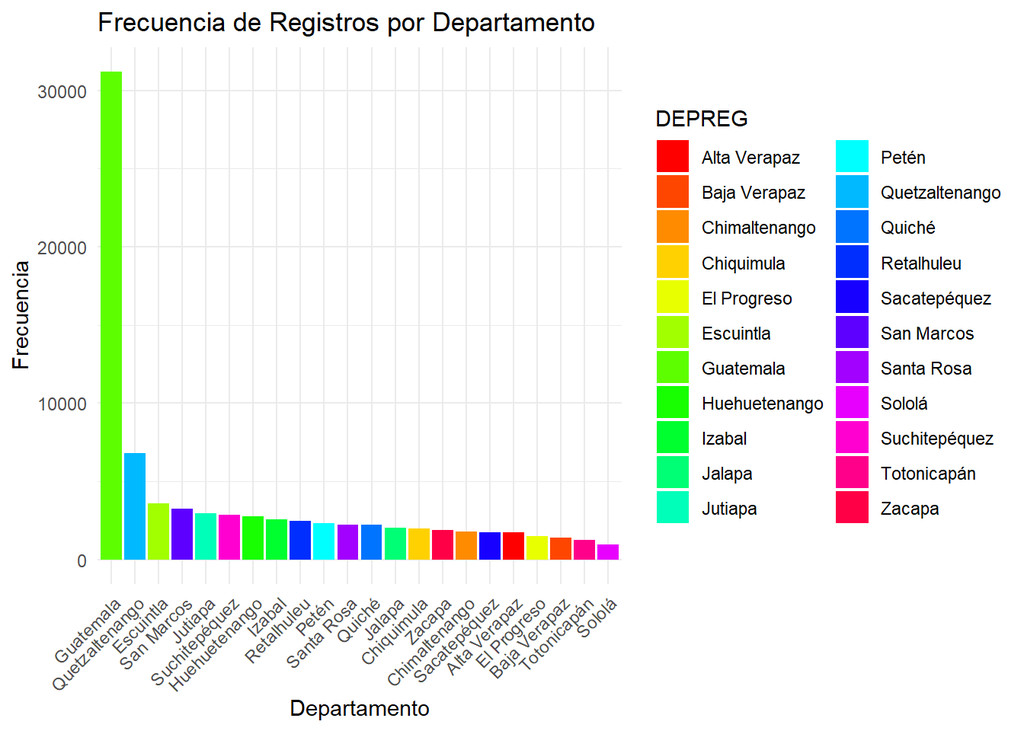

1 Guatemala 2 El Progreso 3 Sacatepéquez 4 Chimaltenango 5 Escuintla 6 Santa Rosa 7 Sololá 8 Totonicapán 9 Quetzaltenango 10 Suchitepéquez 11 Retalhuleu 12 San Marcos 13 Huehuetenango 14 Quiché 15 Baja Verapaz 16 Alta Verapaz 17 Petén 18 Izabal 19 Zacapa 20 Chiquimula 21 Jalapa 22 Jutiapa

Con estos datos posiblemente podemos realizar un analisis ante la relación entre el pueblo o etnia de las personas divorciadas y el departamento donde se registró el divorcio.

```
##     MUPREG Frecuencia
## 1      101      23848
## 2      102        354
## 3      103        345
## 4      104        142
## 5      105        134
## 6      106        589
## 7      107         91
## 8      108        649
## 9      109        196
## 10     110        181
## 11     111        564
## 12     112         56
## 13     113        197
## 14     114       1024
```

[output cut: 322 more lines]

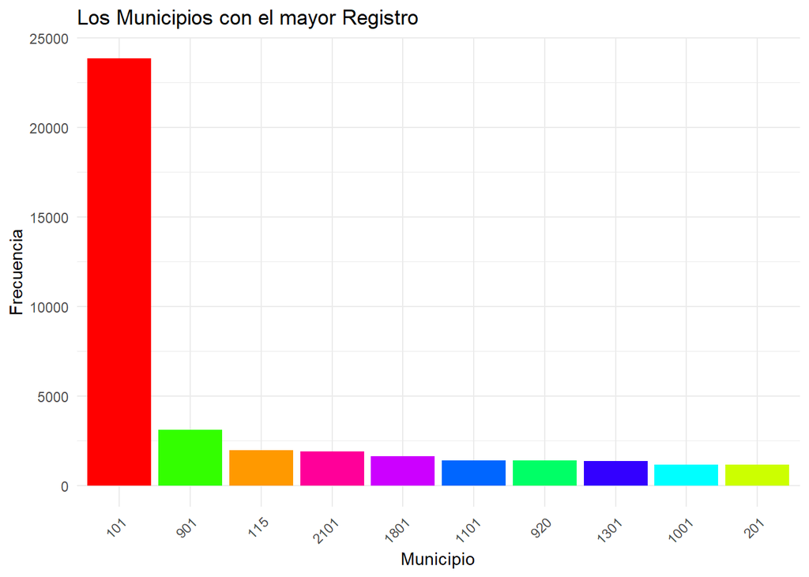

## Que departamento es más frecuente en registrar la ocurrencia del divorcio.

```
##            DEPOCU Frecuencia
## 1    Alta Verapaz       1783
## 2    Baja Verapaz       1587
## 3   Chimaltenango       1761
## 4      Chiquimula       2062
## 5     El Progreso       1454
## 6       Escuintla       3993
## 7       Guatemala      29942
## 8   Huehuetenango       2926
## 9          Izabal       2654
## 10         Jalapa       1793
## 11        Jutiapa       3537
## 12          Petén       2226
## 13 Quetzaltenango       6255
## 14         Quiché       2327
## 15     Retalhuleu       2432
## 16   Sacatepéquez       1712
## 17     San Marcos       3598
## 18     Santa Rosa       2320
## 19         Sololá        968
## 20  Suchitepéquez       3060
## 21    Totonicapán       1489
## 22         Zacapa       1947
```

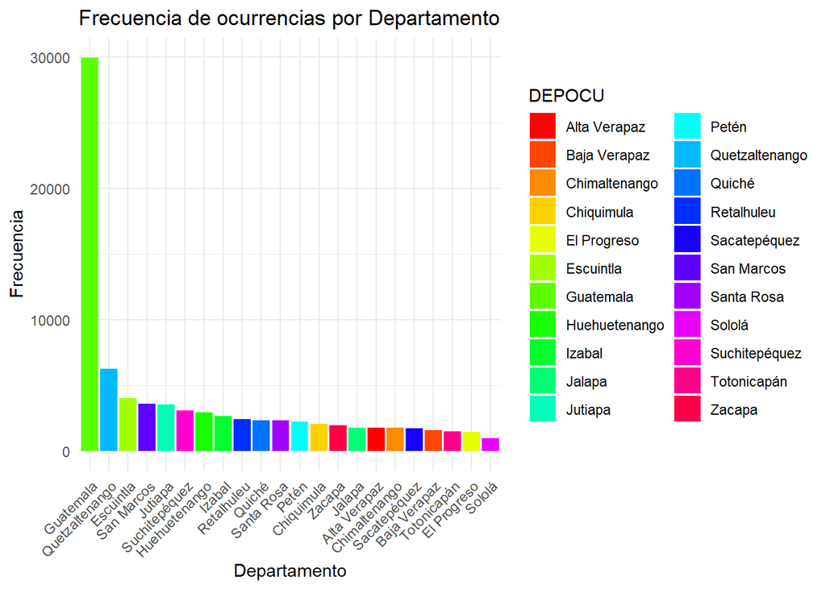

```
##     MUPOCU Frecuencia
## 1      101      20197
## 2      102        468
## 3      103        433
## 4      104        105
## 5      105        191
## 6      106        518
## 7      107        175
## 8      108       2478
## 9      109        165
## 10     110        390
## 11     111        169
## 12     112         38
## 13     113        200
## 14     114        981
```

[output cut: 323 more lines]

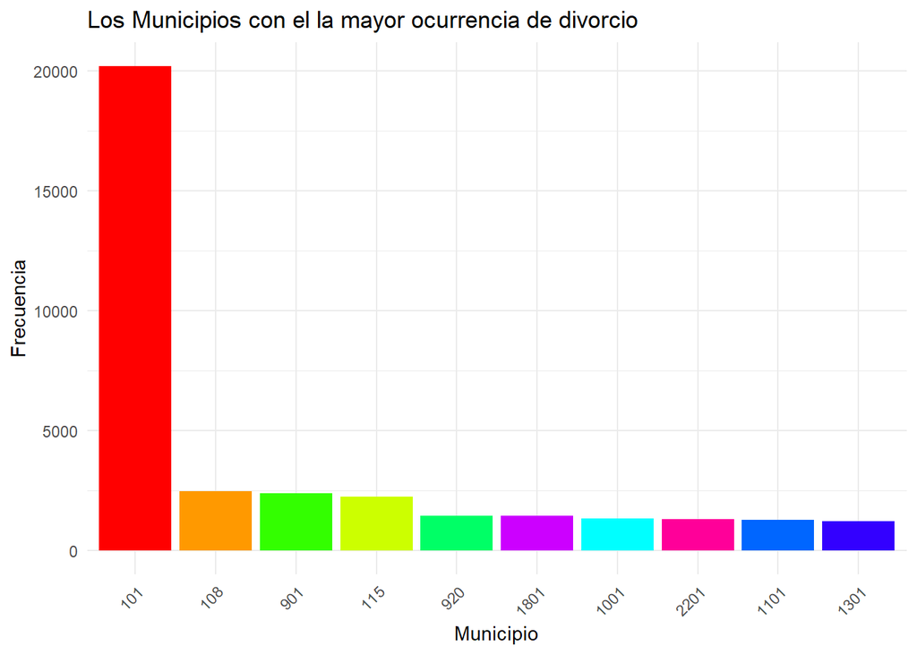

Se confirma también cómo, en el departamento, tienen diferentes datos los registros y las ocurrencias, lo cual indica que son variables diferentes. Sin embargo, lo que más se observa es que el municipio de Guatemala tiene la mayor frecuencia en la ocurrencia de divorcio.

```
##             PUEHOM Frecuencia
## 1         Garífuna       1143
## 2         Ignorado      41402
## 3             Maya       6291
## 4 Mestizo / Ladino      32369
## 5             Otro        609
## 6            Xinka         12
```

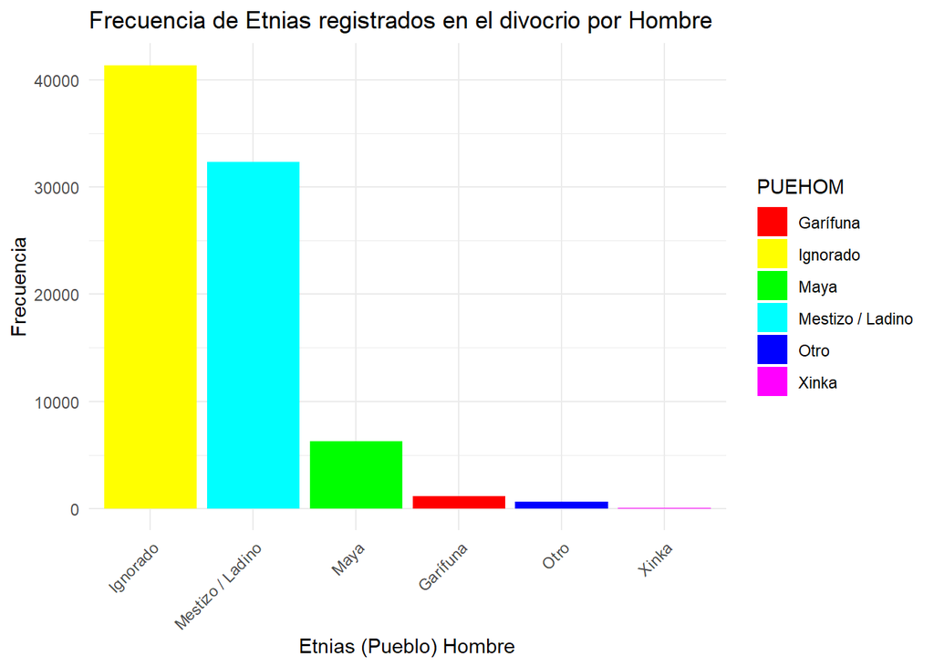

1 Maya 2 Garífuna 3 Xinka 4 Mestizo / Ladino 5 Otro 9 Ignorado

## Mujer

```
##             PUEMUJ Frecuencia
## 1         Garífuna       1171
## 2         Ignorado      41511
## 3             Maya       5820
## 4 Mestizo / Ladino      32621
## 5             Otro        687
## 6            Xinka         16
```

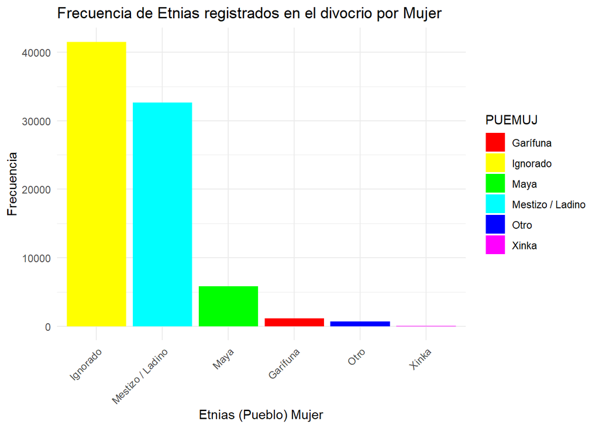

1 Maya 2 Garífuna 3 Xinka 4 Mestizo / Ladino 5 Otro 9 Ignorado

Se observa que la mayor frecuencia es IGNORADO aunque observamos en el segundo puesto que los Mestizos/Ladinos con un total de 32621 registros, luego estan Maya y la menor frecuencia, se encuentra el pueblo Xinka con un total de 16 registros.

## Nacionalidad de la Hombre

```
##    NACHOM Frecuencia
## 1      10          2
## 2      32         22
## 3      36          2
## 4      40          5
## 5      56          1
## 6      68          8
## 7      76          9
## 8      84          9
## 9     100          1
## 10    124         18
## 11    152         15
## 12    156         10
## 13    170         51
## 14    188         37
```

[output cut: 57 more lines]

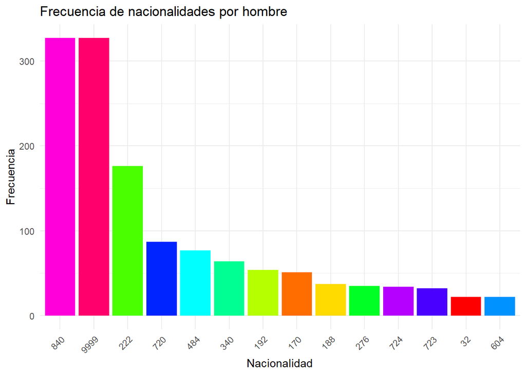

Tomar nota de que no se agregó la nacionalidad Guatemala debido a que sabemos que tiene un mayor porcentaje. Solo observaremos las de otras nacionalidades para ver cuál es la más frecuente. Se observa que Estados Unidos y la variable IGNORADO son las más frecuentes, ya que tienen 327 datos.

```
##   NACMUJ Frecuencia
## 1     32         15
## 2     36          1
## 3     40          2
## 4     56          3
## 5     68          1
## 6     76          9
```

[figure not shown]

Tomar nota de que no se agregó la nacionalidad Guatemala debido a que sabemos que tiene un mayor porcentaje. Solo observaremos las de otras nacionalidades para ver cuál es la más frecuente. Se observa que Estados Unidos es más frecuente que la variable IGNORADO lo cual hace la mayor frecuente nacionalidad.

## Escolaridad

```
##          ESCHOM Frecuencia
## 1        Básica       6334
## 2 Diversificado      15951
## 3      Ingorado      36789
## 4       Ninguno       9660
## 5     Postgrado        157
## 6      Primaria       7936
## 7 Universitario       4542
```

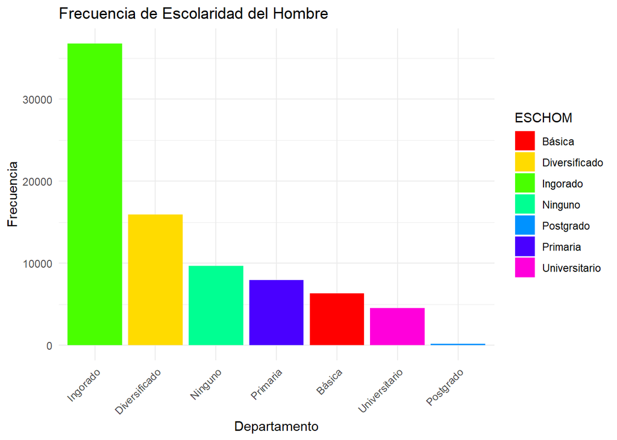

1 Ninguno 2 Primaria 3 Básica 4 Diversificado 5 Universitario 6 Postgrado 9 Ignorado

Se observa que la mayor frecuencia corresponde a la variable IGNORADO, lo cual no nos indica si la población está educada o no. Por otro lado, observamos que la variable ‘diversificado’ (15,951) es la más frecuente y tiene cierta significancia. Otro dato importante a resaltar es que la variable ‘ninguno’ es la tercera más frecuente, lo cual podríamos relacionar con la causa del divorcio, si esta está vinculada con la educación.

```
##          ESCMUJ Frecuencia
## 1        Básica       6275
## 2 Diversificado      16452
## 3      Ingorado      36358
## 4       Ninguno      10067
## 5     Postgrado        109
## 6      Primaria       7622
## 7 Universitario       4401
```

[figure not shown]

## Ocupacion Hombres

```
##    CIUOHOM Frecuencia
## 1        1         88
## 2        3         82
## 3       11         77
## 4       12        306
## 5       13         41
## 6       14          8
## 7       21       1195
## 8       22        602
## 9       23       2192
## 10      24        618
## 11      25        252
## 12      26        855
## 13      31       1581
## 14      32        208
```

[output cut: 30 more lines]

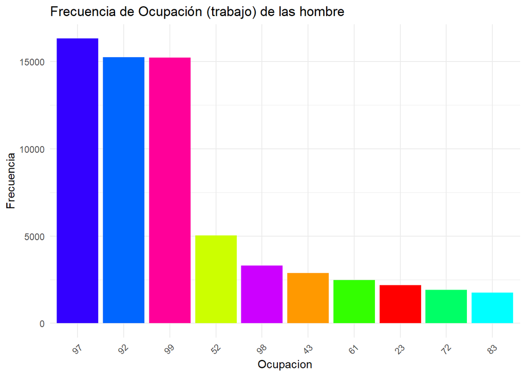

```
##    CIUOMUJ Frecuencia
## 1        1          9
## 2        3          5
## 3       11         40
## 4       12        225
## 5       13          5
## 6       14         14
## 7       21        479
## 8       22        613
## 9       23       4591
## 10      24        533
## 11      25         55
## 12      26       1036
## 13      31        145
## 14      32        547
```

[output cut: 28 more lines]

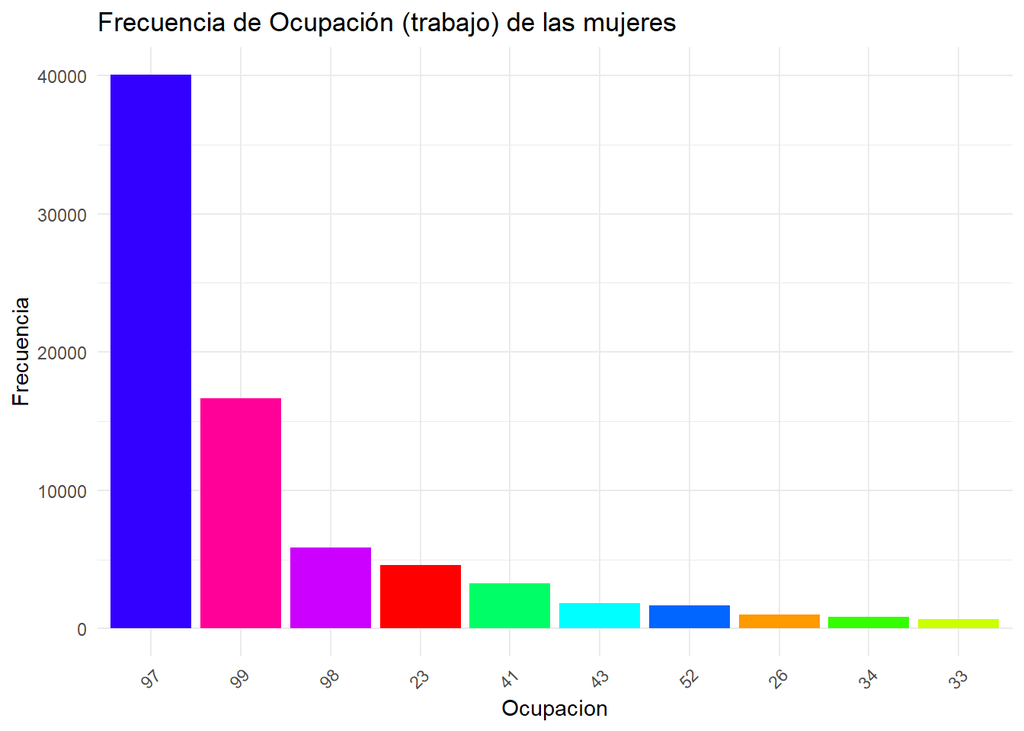

Se observa que la variable con mayor frecuencia es “No especificado en otro grupo”, lo cual puede representar cualquier ocupación no mencionada. Por otro lado, observamos que 99 y 98 corresponden a otra variable que no tiene gran significancia, ya que se clasifica como “Ignorado”. Además, se puede notar que el dato 23 tiene relevancia, ya que representa ocupaciones de peones agropecuarios, pesqueros y forestales, siendo uno de los datos más frecuentes.